# R Notebook

# Set up and load relevant packages

```r
if (!require("pacman")) install.packages("pacman");
library(pacman)
pacman::p_load(tidyverse, dplyr, nycflights13)

#pacman installs a package before loading it if it is not already installed
```

Make a scatterplot of hwy vs cyl.

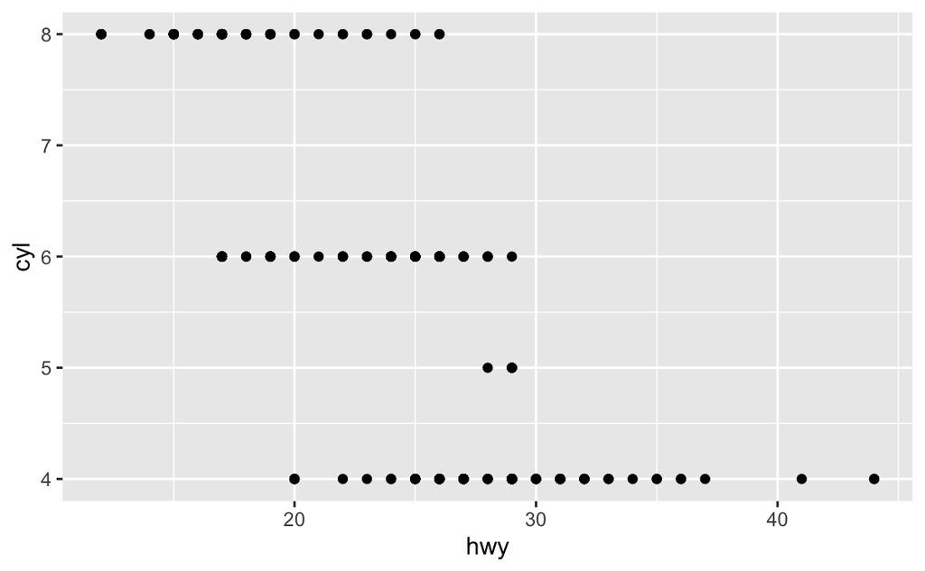

```r
ggplot(mpg, aes(x = hwy, y = cyl)) +
  geom_point()
```

What happens if you make a scatterplot of class vs drv? Why is the plot not useful? What happens if you use geom_count() instead?

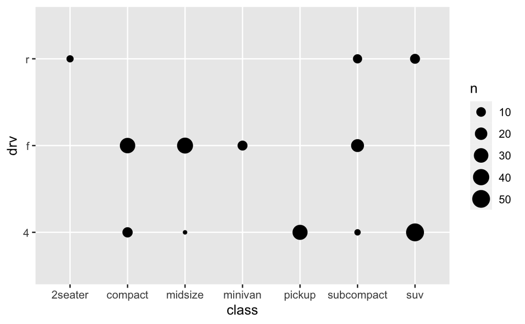

What’s gone wrong with this code? Why are the points not blue?

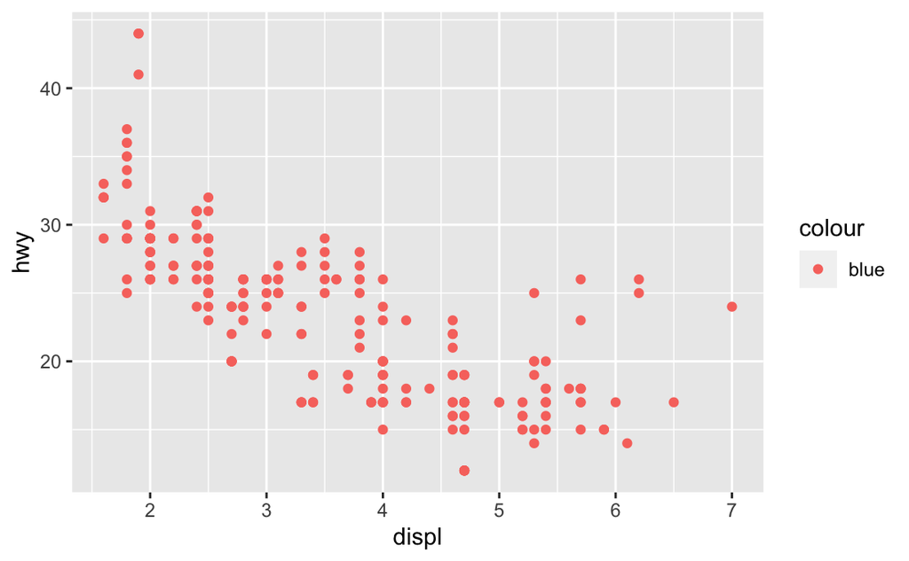

```r
ggplot(data = mpg) + geom_point(mapping = aes(x = displ, y = hwy, color = "blue"))
```

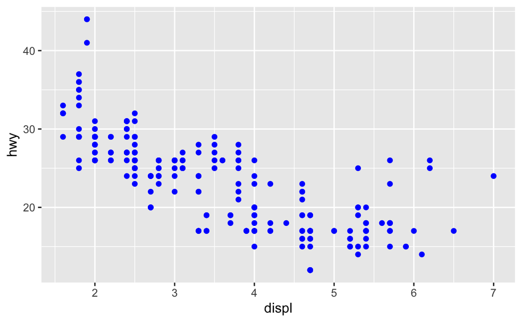

Map a continuous variable to color, size, and shape. How do these aesthetics behave differently for categorical vs. continuous variables?

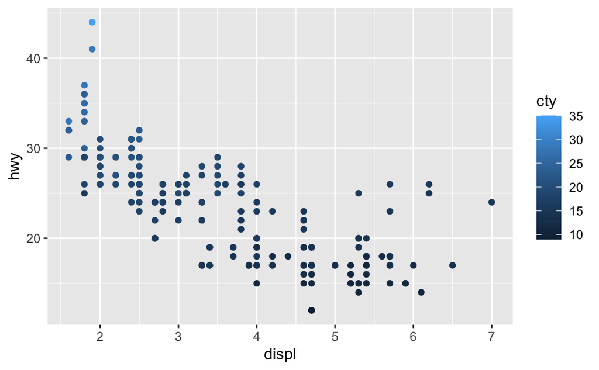

```r
ggplot(mpg, aes(x = displ, y = hwy, colour = cty)) +
  geom_point()
```

What happens if you map the same variable to multiple aesthetics?

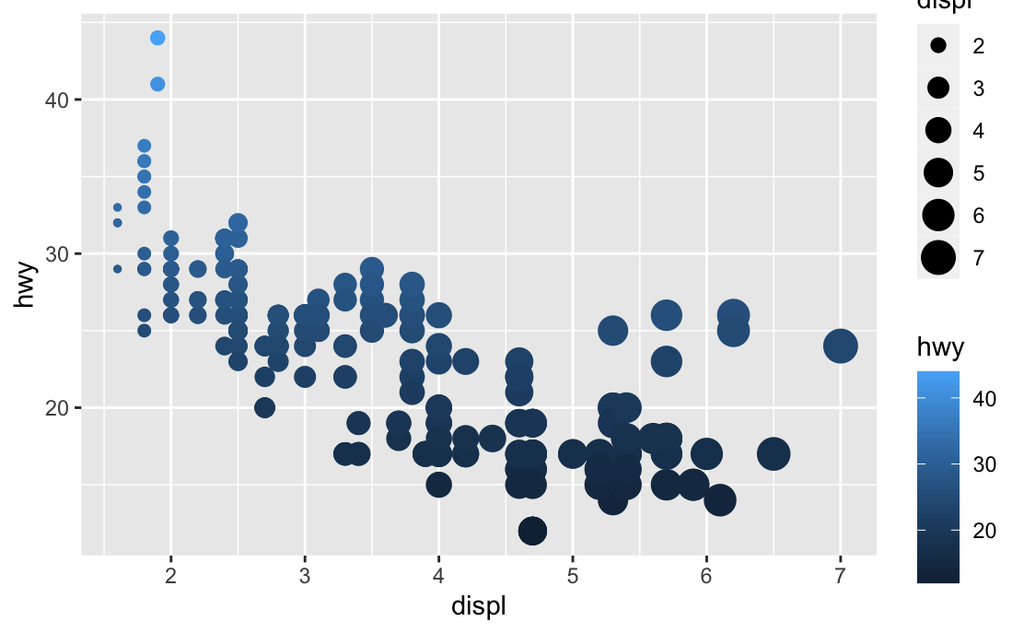

```r
ggplot(mpg, aes(x = displ, y = hwy, colour = hwy, size = displ)) +
  geom_point()
```

```r
#The code works and produces a plot, even if it is a bad one. Mapping a single variable to multiple aesthetics is redundant. Because it is redundant information, in most cases avoid mapping a single variable to multiple aesthetics.
```

What does the stroke aesthetic do? What shapes does it work with? (Hint: use ?geom_point)

What happens if you map an aesthetic to something other than a variable name, like aes(colour = displ < 5)? Note, you’ll also need to specify x and y.

What plots does the following code make? What does . do?

```r
ggplot(data = mpg) + geom_point(mapping = aes(x = displ, y = hwy)) + facet_grid(drv ~ .)
```

[output not shown]

Run this code in your head and predict what the output will look like. Then, run the code in R and check your predictions.

```r
ggplot(data = mpg, mapping = aes(x = displ, y = hwy, color = drv)) + geom_point() + geom_smooth(se = FALSE)
```

[output not shown]

What does the se argument to geom_smooth() do?

What is the default geom associated with stat_summary()?

What does geom_col() do? How is it different to geom_bar()?

Create one plot on the fuel economy data with customized title, subtitle, caption, x, y, and colour labels.